# Coffee over Statistical Methods for Decision Making

~Shikhar Parashar

September 27, 2017

**MENTOR: Dr. Bappaditya Mukhopadhyay**

PGP - BA-BI  
Great Lakes Institute Of Management (Class of ’17-’18)

Reading the dataset into R and checking the dimensions of the dataset

```
## [1] 130986     12
```

```
## [1] "Coffee dataset provides 130986 records with 12 columns."
```

Identifing Variables of the coffee dataset and updating behaviour / nature of variables as per the Desc.doc

```
## 'data.frame':    130986 obs. of  12 variables:
##  $ ï..No_of_Packet      : Factor w/ 3 levels "1","2","3": 1 1 1 1 1 1 1 1 1 1 ...
##  $ Price_per_Packet     : Factor w/ 3 levels "1","2","3": 1 1 1 1 2 1 1 1 1 2 ...
##  $ IDNo                 : Factor w/ 2111 levels "1","8","14","17",..: 1 1 1 1 1 1 1 1 1 1 ...
##  $ Brand                : Factor w/ 9 levels "1","2","3","4",..: 4 4 4 4 9 4 9 9 4 9 ...
##  $ Days_between_Purchase: int  11 24 22 24 11 10 12 13 24 4 ...
##  $ Age                  : Factor w/ 5 levels "1","2","3","4",..: 2 2 2 2 2 2 2 2 2 2 ...
##  $ SEC                  : Factor w/ 5 levels "1","2","3","4",..: 5 5 5 5 5 5 5 5 5 5 ...
##  $ Income               : Factor w/ 4 levels "1","2","3","4": 1 1 1 1 1 1 1 1 1 1 ...
##  $ Household_Sz         : Factor w/ 5 levels "1","2","3","4",..: 2 2 2 2 2 2 2 2 2 2 ...
##  $ Price_Conscious      : Factor w/ 4 levels "1","2","3","4": 1 1 1 1 1 1 1 1 1 1 ...
##  $ Education            : Factor w/ 3 levels "1","2","3": 2 2 2 2 2 2 2 2 2 2 ...
##  $ Loyalty              : Factor w/ 2 levels "1","2": 1 1 1 1 2 2 2 1 2 2 ...
```

### Exploratory Data Analysis

Now we further explore the nature of each individual variable in detail.

```
##  ï..No_of_Packet Price_per_Packet      IDNo            Brand
##  1:105022        1:29637          560    :   251   9      :35548
##  2: 19289        2:67374          4627   :   245   8      :20055
##  3:  6675        3:33975          1268   :   243   1      :15662
##                                   985    :   242   3      :13832
##                                   3669   :   239   6      :13274
##                                   2898   :   228   4      : 9370
##                                   (Other):129538   (Other):23245
##  Days_between_Purchase Age       SEC       Income    Household_Sz
##  Min.   :  1.00        1: 2675   1:24203   1:33480   1:21587
##  1st Qu.:  6.00        2:16944   2:22302   2:34543   2:48624
##  Median :  9.00        3:26749   3:49052   3:40557   3:27910
##  Mean   : 15.14        4:46601   4:25830   4:22406   4:20200
##  3rd Qu.: 17.00        5:38017   5: 9599             5:12665
##  Max.   :741.00
##
##  Price_Conscious Education Loyalty
##  1:75051         1:37108   1:75057
##  2:25694         2:38641   2:55929
##  3: 5068         3:55237
##  4:25173
##
##
##
```

### No_of_Packet

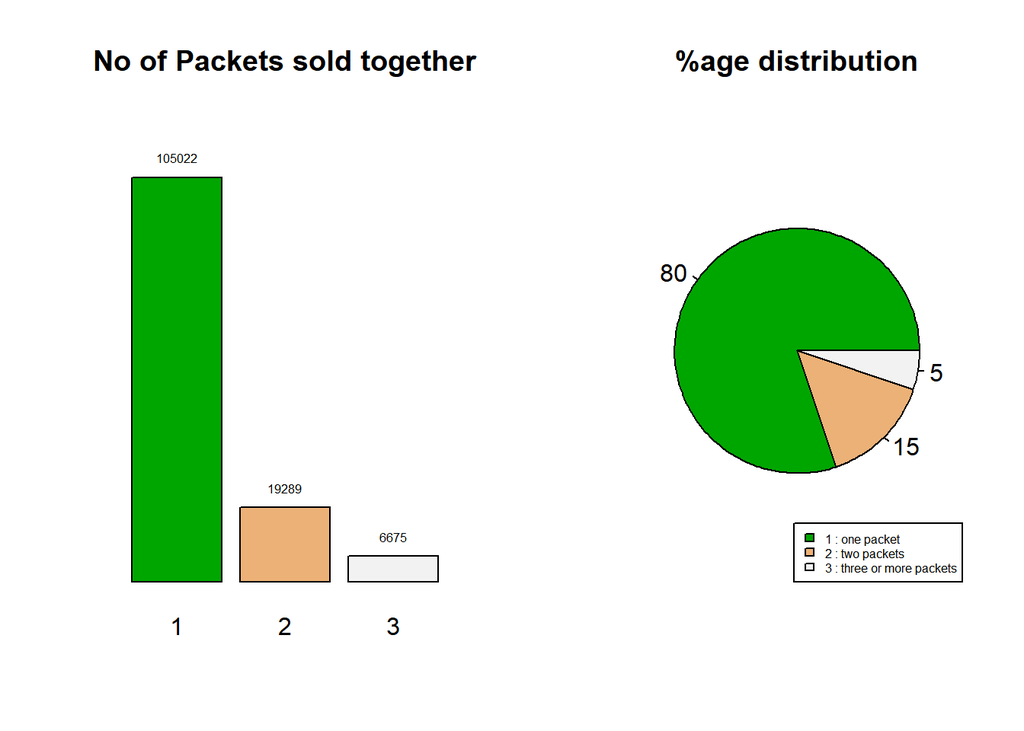

### Price_per_Packet

[figure not shown]

**Conclusion:** *We can see that 51% of all coffee packets are priced between 6,50 DM to 8,50 DM and hence is the dominating price category amongst the 3*

### IDNo

Top 6 Houses with **least number** of Packets Purchased

```
##  663 1665 1680 2005 4081 5773
##    1    1    1    1    1    1
```

Top 6 Houses with **most number** of Packets Purchased

```
## 2898 3669  985 1268 4627  560
##  228  239  242  243  245  251
```

**Conclusion:** *We can see that **House ID: 560** is the largest purchaser of Coffee Packets whereas **House ID: 663, 1665, 1680, 2005, 4081 and 5773** have purchased only 1 packet of Coffee*

### Brand

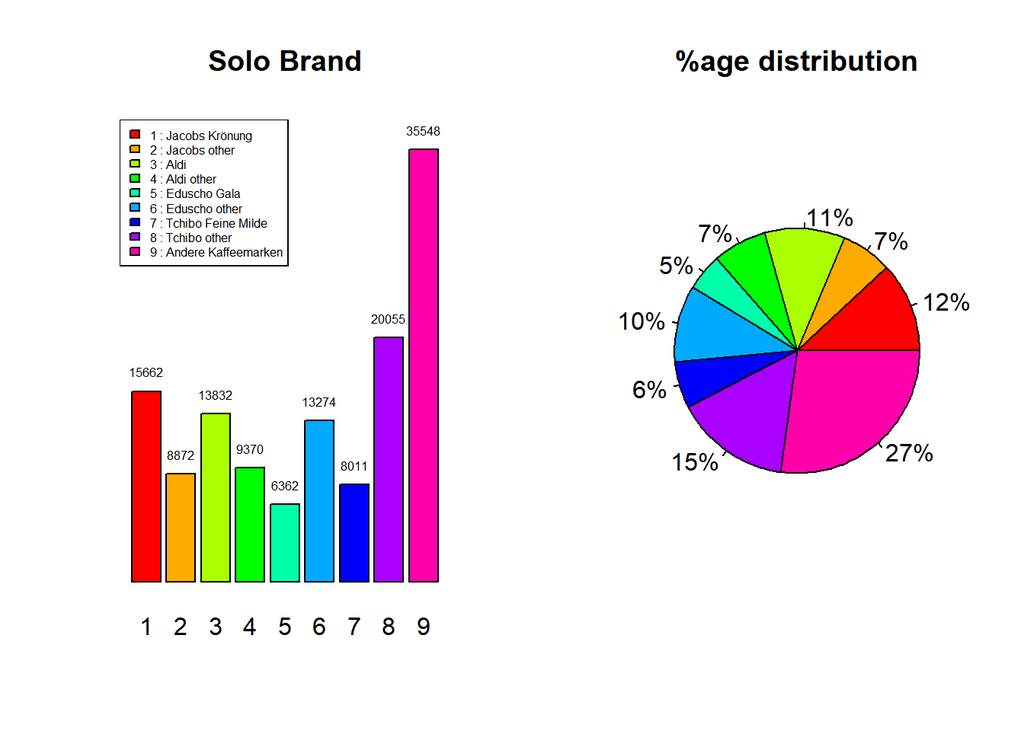

**Conclusion:** *When restricting ourselves to all individual Brands from different competetiors, we notice that the Brand : **Andere Kaffeemarken** has about **27%** market share*

### Company

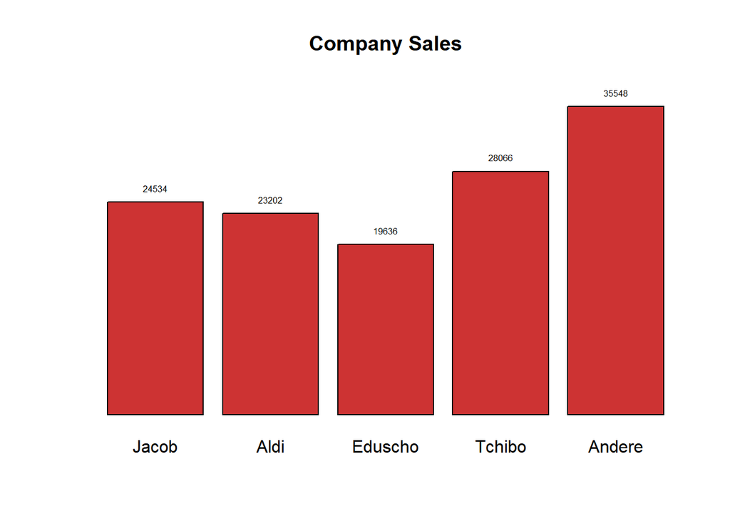

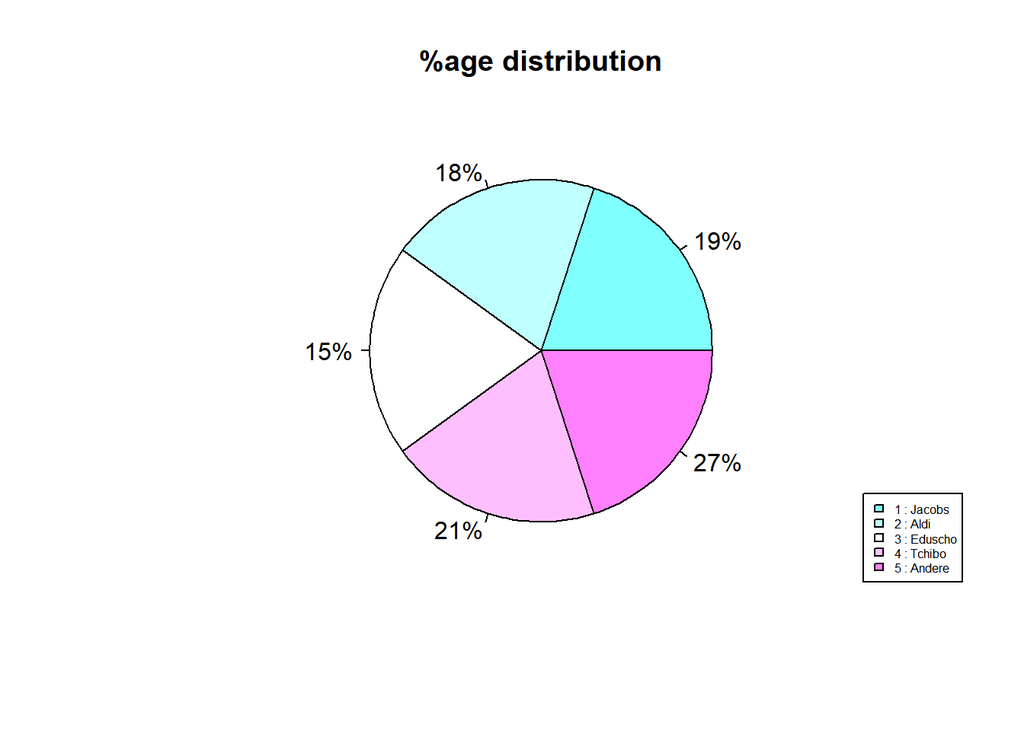

**Conclusion:** *When looking for the Market Share for each company, it is evident that **Andere** leads the race with **27%** market share, followed by **Tchibo, Jacobs, Aldi and Eduscho** respectively.*

### Days_between_Purchase

```
##    Min. 1st Qu.  Median    Mean 3rd Qu.    Max.
##    1.00    6.00    9.00   15.14   17.00  741.00
```

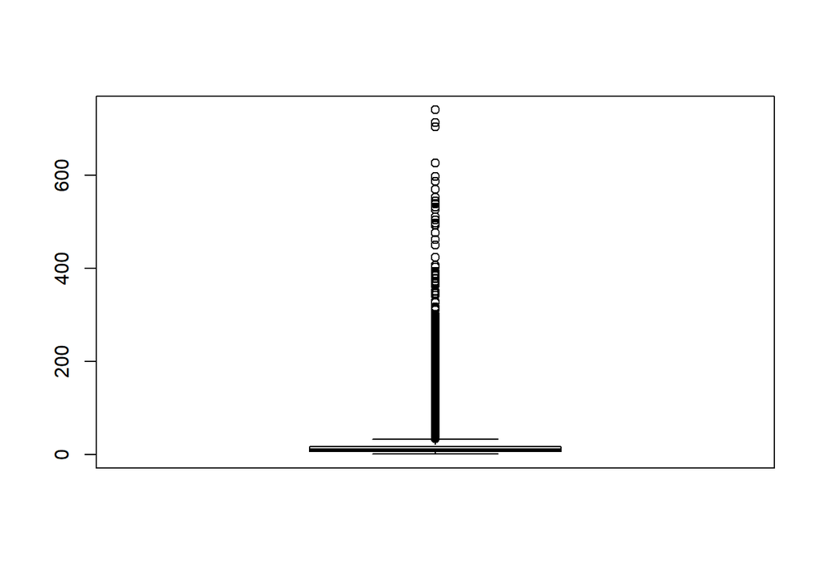

```
## [1] "53.49%" "46.51%"
```

### Age wise Customer Distribution

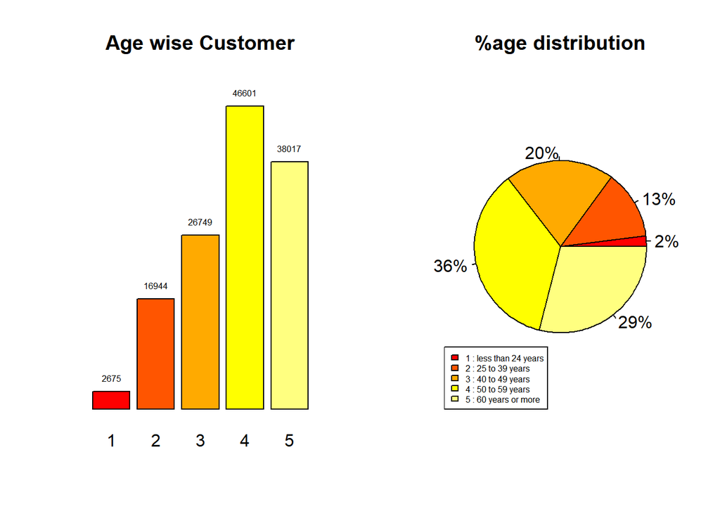

**Conclusion:** *From the above, its crystal clear that, of all the customers researched, people within the Age Bracket of **50 to 59 years** have the highest caffinne intakes whereas people within the age group of **less than 24 years** have the least caffinne intake.*

### Socioeconomic level of householder

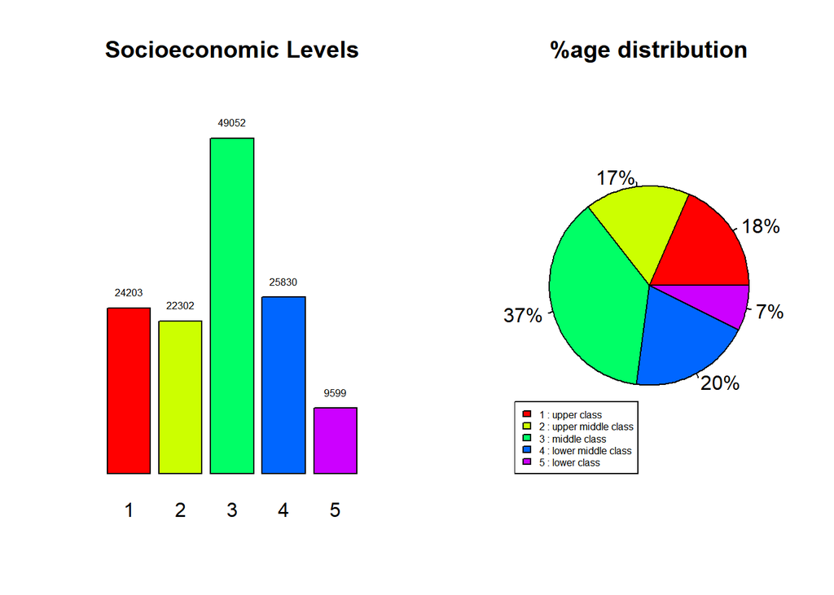

**Conclusion:** **Middle Class** is the Socio Economic class most likely to buy coffee whereas the **Lower Class** is the least likely of all the Socio Economic Classes to buy a packet of Coffee.

### Monthly Household Income

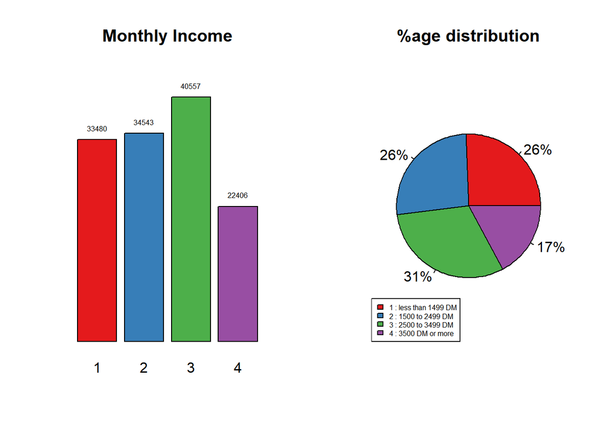

**Conclusion:** Household’s earning **3500 DM or more** happen to be smallest of consumers of Coffee whereas Households earning **between 2500 DM to 3499 DM** are the largest consumers of coffee.

### Household Size

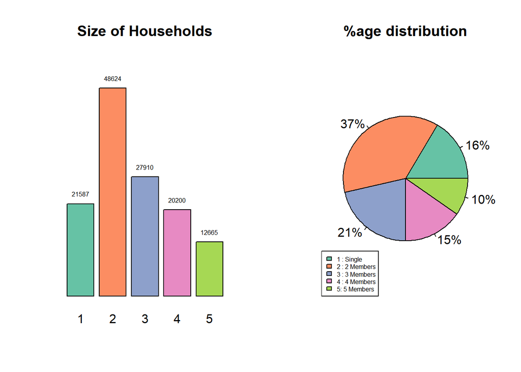

**Conclusion:** It is evident from the above that Small Families have a larger share of the Coffee sales. Households with **3 members or less** account for **75%** share of all coffee packets sold.

### Price Conciousness

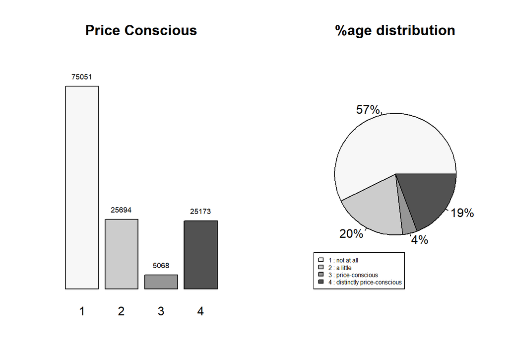

**Conclusion:** With more than **75%** of all consumers either being ‘not at all price concisous’ or ‘a little price concisous’, the segment offers to be a **Marketer’s paradise** for setting the **Product Pricing.**

### Education of householder

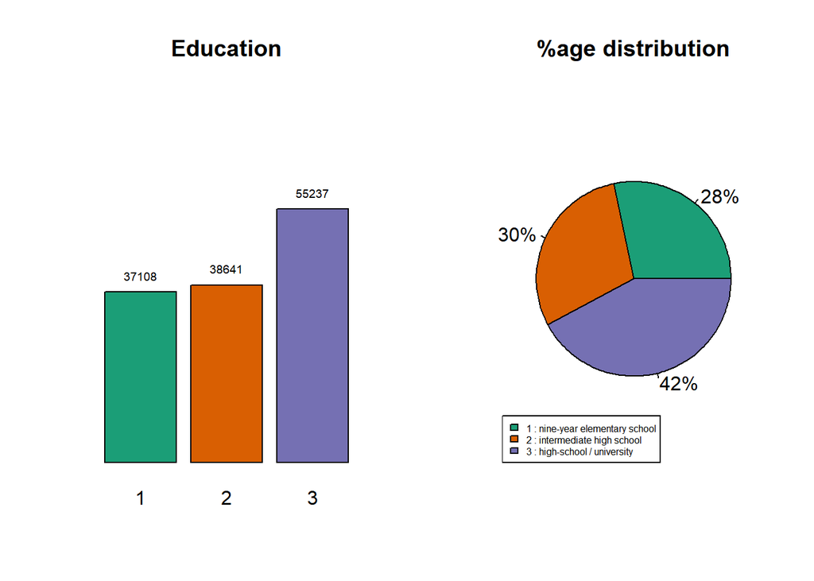

**Conclusion:** Based on Education we can infer that most coffee is consumed by people with **high-school/university** education.

### Brand loyalty

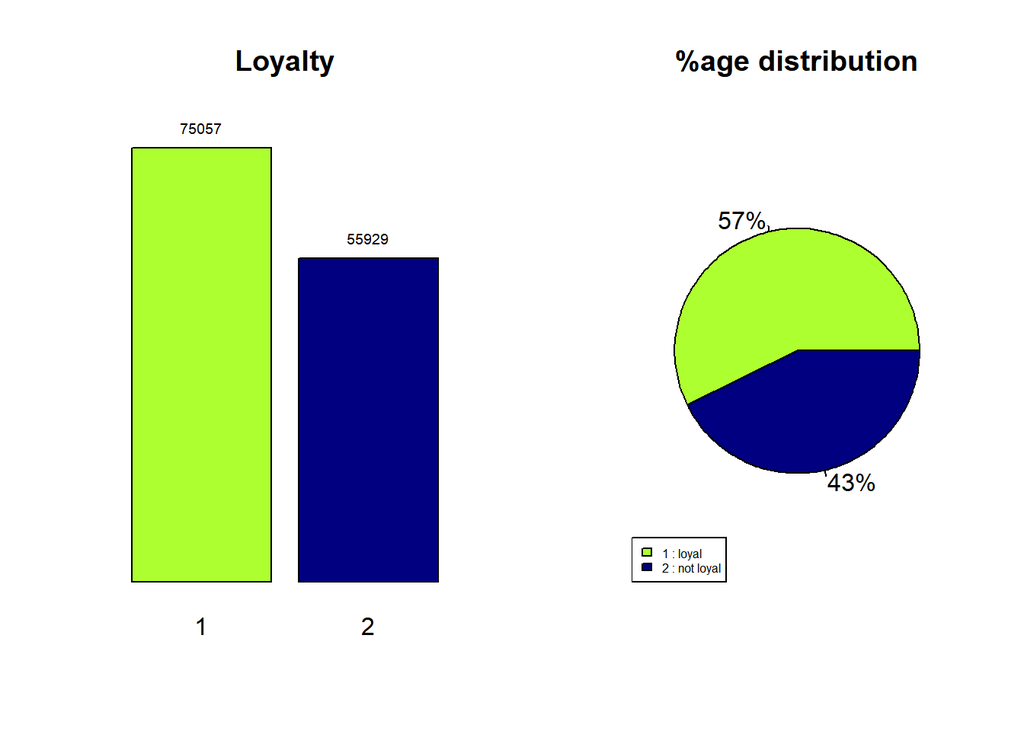

**Conclusion:** Its evident from the above charts that Loyalty is not a big factor when making decisions on coffee. **43%** non-loyal customers against **57%** loyal customers is too close a call based on Loyalty.

## Solutions to questions asked.

1. Which brands of coffee are more popular? Given a brand, are all variants equally preferred?

   ```
   With 27% market share, Andere Kaffeemarken is the most popular individual brand and leader in the segment.
   ```

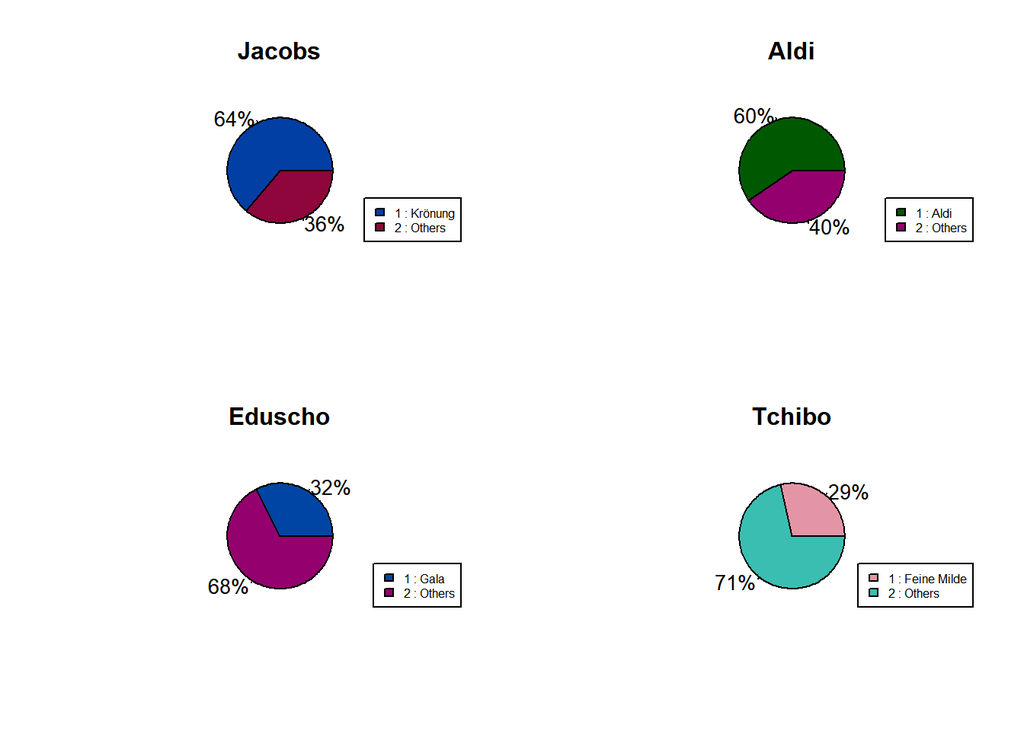

```
Within all four brands, having more than one type of product on the shelves, having varing degree of sales distribution amongst the different types, it can not be concluded that "Given a brand, all variants are equally preferred."
```

2. What are the prices of different brands of coffee?

[figure not shown]

[output not shown]

3. How frequently does a household buy coffee? How many packets of coffee are bought at a time?

[output not shown]

4. What are the factors that have an impact on a household’s coffee purchase pattern? Does brand preference depend on household size? Does purchase depend on a person’s income or education level?

[output not shown]